# Experiment 2: Trust/Interaction/Confidence ~ Lines by Interaction Mode (0330, No Norm)

## Goal

Recreate Experiment 2 preprocessing with raw scores (no within-participant normalization, no CI-condition analysis) and produce only:

- `Trust ~ number of lines` with three groups: `click`, `hover`, `static` (raw-point scatter + best-fit model line)
- `Interactive experience ~ number of lines` with three groups: `click`, `hover`, `static` (raw-point scatter + best-fit model line)
- `Confidence ~ number of lines` with three groups: `click`, `hover`, `static` (raw-point scatter + best-fit model line)

Output:

- 3 raw-point plots (Trust, Interaction, Confidence) colored by `click/hover/static`
- 9 model-comparison tables (3 interaction modes x 3 outcomes)
- 9 optimal-model summaries (best model by `BIC` for each interaction mode x outcome)
- 3 repeated-measures regression tables using only `2` vs `9` lines with interaction mode and participant-level error structure

## Packages

```r
required_packages <- c(
  "dplyr",
  "jsonlite",
  "ggplot2",
  "knitr",
  "lme4",
  "lmerTest"
)

missing_packages <- required_packages[
  !vapply(required_packages, requireNamespace, logical(1), quietly = TRUE)
]

if (length(missing_packages) > 0) {
  stop(
    "Missing required packages: ",
    paste(missing_packages, collapse = ", "),
    ". Install them before rendering."
  )
}

lapply(required_packages, library, character.only = TRUE)
```

[output not shown]

## Paths

```r
report_dir <- local({
  current_input <- tryCatch(
    knitr::current_input(),
    error = function(e) character(0)
  )

  if (length(current_input) == 1 && nzchar(current_input)) {
    input_path <- current_input

    if (!grepl("^(/|[A-Za-z]:[/\\\\])", input_path)) {
      input_path <- file.path(getwd(), input_path)
    }

    if (grepl("\\.[Rr]md$", input_path) || file.exists(input_path)) {
      return(normalizePath(dirname(input_path), winslash = "/", mustWork = TRUE))
    }
  }

  fallback_dir <- file.path(getwd(), "Experiment2", "analysis")
  normalizePath(fallback_dir, winslash = "/", mustWork = TRUE)
})

resolve_report_path <- function(path_value) {
  if (grepl("^(/|[A-Za-z]:[/\\\\])", path_value)) {
    return(normalizePath(path_value, winslash = "/", mustWork = TRUE))
  }

  normalizePath(
    file.path(report_dir, path_value),
    winslash = "/",
    mustWork = TRUE
  )
}

data_dir_candidates <- vapply(params$data_dir_candidates, resolve_report_path, character(1))
existing_data_dirs <- data_dir_candidates[dir.exists(data_dir_candidates)]

if (length(existing_data_dirs) != length(data_dir_candidates)) {
  missing_dirs <- setdiff(data_dir_candidates, existing_data_dirs)
  stop(
    "Missing required data directory(ies): ",
    paste(missing_dirs, collapse = ", ")
  )
}
```

## Constants

```r
CONDITION_LABELS <- c(
  "1" = "Baseline",
  "2" = "CI",
  "3" = "2 Lines",
  "4" = "3 Lines",
  "5" = "4 Lines",
  "6" = "5 Lines",
  "7" = "6 Lines",
  "8" = "7 Lines",
  "9" = "8 Lines",
  "10" = "9 Lines"
)

BASELINE_CONDITION_NUMBER <- 1
TREATMENT_CONDITION_NUMBERS <- c(3, 4, 5, 6, 7, 8, 9, 10)
TREATMENT_ORDER <- c("2 Lines", "3 Lines", "4 Lines", "5 Lines", "6 Lines", "7 Lines", "8 Lines", "9 Lines")

TRUST_QUESTION_KEYS <- c(
  "skeptical_rating",
  "data_trust",
  "usability_difficulty",
  "comprehension_ease"
)

INTERACTION_QUESTION_KEYS <- c(
  "navigation_control",
  "content_control",
  "pace_control",
  "interface_exploration",
  "interface_responsiveness",
  "user_communication",
  "personal_conversation",
  "interface_interaction",
  "interface_sensitivity"
)

CONFIDENCE_QUESTION_KEYS <- c("confidence_rating")

NORMALIZED_FLAG_COLUMN <- "_cousineau_normalized"
MOREY_FACTOR_COLUMN <- "_morey_factor"
K_CONDITIONS_COLUMN <- "_k_conditions"
LASSO_LAMBDA <- 0.05
```

## Helper Functions

```r
extract_condition_number <- function(condition_id) {
  if (is.na(condition_id) || !nzchar(as.character(condition_id))) {
    return(NA_real_)
  }

  raw <- sub(".*condition_([0-9]+).*", "\\1", as.character(condition_id), perl = TRUE)
  if (!grepl("^[0-9]+$", raw)) {
    return(NA_real_)
  }

  as.numeric(raw)
}

map_condition_labels <- function(condition_numbers) {
  vapply(
    condition_numbers,
    function(x) {
      key <- as.character(suppressWarnings(as.integer(x)))
      if (is.na(x) || !(key %in% names(CONDITION_LABELS))) {
        return("Other")
      }
      CONDITION_LABELS[[key]]
    },
    character(1)
  )
}

extract_participant_id_from_filename <- function(file_path) {
  parts <- strsplit(tools::file_path_sans_ext(basename(file_path)), "_", fixed = TRUE)[[1]]
  if (length(parts) >= 2) {
    return(parts[[2]])
  }
  NA_character_
}

parse_response_json <- function(value) {
  if (is.null(value) || length(value) == 0 || is.na(value) || !nzchar(as.character(value))) {
    return(list())
  }

  if (is.list(value) && !is.null(names(value))) {
    return(value)
  }

  parsed <- tryCatch(
    jsonlite::fromJSON(as.character(value), simplifyVector = TRUE),
    error = function(e) NULL
  )

  if (is.null(parsed) || !is.list(parsed)) {
    return(list())
  }

  parsed
}

safe_get_scalar <- function(x) {
  if (is.null(x) || length(x) == 0) {
    return(NA_character_)
  }

  as.character(x[[1]])
}

expand_response_columns <- function(data, response_col = "response") {
  if (!(response_col %in% names(data))) {
    return(data)
  }

  parsed_list <- lapply(data[[response_col]], parse_response_json)
  all_keys <- unique(unlist(lapply(parsed_list, names), use.names = FALSE))

  if (length(all_keys) == 0) {
    return(data)
  }

  expanded <- data.frame(
    lapply(all_keys, function(key) {
      vapply(parsed_list, function(item) safe_get_scalar(item[[key]]), character(1))
    }),
    stringsAsFactors = FALSE,
    check.names = FALSE
  )
  names(expanded) <- all_keys

  merged <- data
  for (col in names(expanded)) {
    parsed_values <- expanded[[col]]

    if (col %in% names(merged)) {
      existing <- merged[[col]]
      existing_chr <- trimws(as.character(existing))
      fill_mask <- is.na(existing) | existing_chr == ""
      existing[fill_mask] <- parsed_values[fill_mask]
      merged[[col]] <- existing
    } else {
      merged[[col]] <- parsed_values
    }
  }

  merged
}

identify_attention_check_failures <- function(
  data,
  trust_keys = TRUST_QUESTION_KEYS,
  interaction_keys = INTERACTION_QUESTION_KEYS,
  survey_trial_type = "trust-survey"
) {
  empty_result <- list(ids = character(0), details = data.frame())

  if (is.null(data) || nrow(data) == 0) {
    return(empty_result)
  }

  if (!all(c("trial_type", "participant_id") %in% names(data))) {
    return(empty_result)
  }

  survey_rows <- data[data$trial_type == survey_trial_type, , drop = FALSE]
  if (nrow(survey_rows) == 0) {
    return(empty_result)
  }

  survey_rows <- expand_response_columns(survey_rows)
  parsed_response <- if ("response" %in% names(survey_rows)) {
    lapply(survey_rows$response, parse_response_json)
  } else {
    replicate(nrow(survey_rows), list(), simplify = FALSE)
  }

  for (key in c(trust_keys, interaction_keys)) {
    existing <- if (key %in% names(survey_rows)) {
      suppressWarnings(as.numeric(survey_rows[[key]]))
    } else {
      rep(NA_real_, nrow(survey_rows))
    }

    if (sum(!is.na(existing)) == 0) {
      extracted <- vapply(parsed_response, function(item) safe_get_scalar(item[[key]]), character(1))
      existing <- suppressWarnings(as.numeric(extracted))
    }

    survey_rows[[key]] <- existing
  }

  trust_complete <- rowSums(is.na(survey_rows[, trust_keys, drop = FALSE])) == 0
  interaction_complete <- rowSums(is.na(survey_rows[, interaction_keys, drop = FALSE])) == 0

  trust_uniform <- apply(
    survey_rows[, trust_keys, drop = FALSE],
    1,
    function(row) {
      values <- unique(row[!is.na(row)])
      length(values) == 1
    }
  )

  interaction_uniform <- apply(
    survey_rows[, interaction_keys, drop = FALSE],
    1,
    function(row) {
      values <- unique(row[!is.na(row)])
      length(values) == 1
    }
  )

  failure_mask <- trust_complete & interaction_complete & trust_uniform & interaction_uniform
  failure_rows <- survey_rows[failure_mask & !is.na(survey_rows$participant_id), , drop = FALSE]

  if (nrow(failure_rows) == 0) {
    return(empty_result)
  }

  failure_rows$participant_id <- as.character(failure_rows$participant_id)
  detail_columns <- c(
    "participant_id",
    "condition_id",
    "condition_number",
    trust_keys,
    interaction_keys
  )
  available_detail_columns <- detail_columns[detail_columns %in% names(failure_rows)]

  list(
    ids = unique(failure_rows$participant_id),
    details = failure_rows[, available_detail_columns, drop = FALSE]
  )
}

normalize_scores_cousineau_morey <- function(
  data,
  metric_columns,
  baseline_condition = BASELINE_CONDITION_NUMBER,
  drop_baseline = TRUE,
  normalization_conditions = NULL,
  require_complete_participants = TRUE
) {
  if (is.null(data) || nrow(data) == 0) {
    normalized <- if (is.null(data)) data.frame() else data
    if (nrow(normalized) > 0) {
      normalized[[NORMALIZED_FLAG_COLUMN]] <- FALSE
      normalized[[MOREY_FACTOR_COLUMN]] <- NA_real_
      normalized[[K_CONDITIONS_COLUMN]] <- NA_real_
    }
    return(normalized)
  }

  normalized <- data

  if (!all(c("participant_id", "condition_number") %in% names(normalized))) {
    normalized[[NORMALIZED_FLAG_COLUMN]] <- FALSE
    normalized[[MOREY_FACTOR_COLUMN]] <- NA_real_
    normalized[[K_CONDITIONS_COLUMN]] <- NA_real_
    return(normalized)
  }

  available_columns <- metric_columns[metric_columns %in% names(normalized)]
  normalized$condition_number <- suppressWarnings(as.numeric(normalized$condition_number))
  normalized$.row_id <- seq_len(nrow(normalized))
  normalized[[NORMALIZED_FLAG_COLUMN]] <- FALSE
  normalized[[MOREY_FACTOR_COLUMN]] <- NA_real_
  normalized[[K_CONDITIONS_COLUMN]] <- NA_real_
```

```r
  return_without_norm <- function(df) {
    df$.row_id <- NULL
    if (drop_baseline) {
      df <- df[df$condition_number != baseline_condition, , drop = FALSE]
    }
    df
  }

  if (length(available_columns) == 0) {
    return(return_without_norm(normalized))
  }

  if (is.null(normalization_conditions)) {
    observed_conditions <- sort(unique(stats::na.omit(as.integer(normalized$condition_number))))
    normalization_conditions <- observed_conditions[observed_conditions != as.integer(baseline_condition)]
  } else {
    normalization_conditions <- sort(unique(as.integer(normalization_conditions)))
  }

  if (length(normalization_conditions) == 0) {
    return(return_without_norm(normalized))
  }

  normalization_data <- normalized[normalized$condition_number %in% normalization_conditions, , drop = FALSE]
  if (nrow(normalization_data) == 0) {
    return(return_without_norm(normalized))
  }

  expected_k <- length(normalization_conditions)

  if (require_complete_participants) {
    participant_condition_counts <- stats::aggregate(
      condition_number ~ participant_id,
      data = normalization_data,
      FUN = function(x) length(unique(x[!is.na(x)]))
    )

    complete_participants <- as.character(
      participant_condition_counts$participant_id[
        participant_condition_counts$condition_number >= expected_k
      ]
    )

    normalization_data <- normalization_data[
      as.character(normalization_data$participant_id) %in% complete_participants,
      ,
      drop = FALSE
    ]
  }

  if (nrow(normalization_data) == 0) {
    return(return_without_norm(normalized))
  }

  normalization_row_ids <- normalization_data$.row_id

  for (col in available_columns) {
    numeric_values <- suppressWarnings(as.numeric(normalization_data[[col]]))
    participant_means <- ave(
      numeric_values,
      normalization_data$participant_id,
      FUN = function(x) {
        mean_value <- mean(x, na.rm = TRUE)
        if (is.nan(mean_value)) {
          return(NA_real_)
        }
        mean_value
      }
    )

    grand_mean <- mean(numeric_values, na.rm = TRUE)
    if (is.nan(grand_mean)) {
      grand_mean <- NA_real_
    }

    normalized_values <- numeric_values - participant_means + grand_mean
    normalized[[col]][normalization_row_ids] <- normalized_values
  }

  morey_factor <- if (expected_k > 1) sqrt(expected_k / (expected_k - 1)) else NA_real_
  normalized[[NORMALIZED_FLAG_COLUMN]][normalization_row_ids] <- TRUE
  normalized[[MOREY_FACTOR_COLUMN]][normalization_row_ids] <- morey_factor
  normalized[[K_CONDITIONS_COLUMN]][normalization_row_ids] <- expected_k

  return_without_norm(normalized)
}

ensure_likert_columns <- function(data, keys) {
  if (is.null(data) || nrow(data) == 0) {
    return(data)
  }

  working <- data
  parsed <- if ("response" %in% names(working)) {
    lapply(working$response, parse_response_json)
  } else {
    replicate(nrow(working), list(), simplify = FALSE)
  }

  for (key in keys) {
    existing <- if (key %in% names(working)) {
      suppressWarnings(as.numeric(working[[key]]))
    } else {
      rep(NA_real_, nrow(working))
    }

    if (!(key %in% names(working)) || sum(!is.na(existing)) == 0) {
      extracted <- suppressWarnings(as.numeric(
        vapply(parsed, function(item) safe_get_scalar(item[[key]]), character(1))
      ))

      valid <- extracted[!is.na(extracted)]
      if (length(valid) > 0 && all(valid >= 0 & valid <= 6)) {
        extracted <- extracted + 1
      }

      working[[key]] <- extracted
    } else {
      working[[key]] <- existing
    }
  }

  working
}

compute_composite_scores <- function(data) {
  if (is.null(data) || nrow(data) == 0) {
    return(data.frame())
  }

  working <- data
  for (col in c(TRUST_QUESTION_KEYS, INTERACTION_QUESTION_KEYS, CONFIDENCE_QUESTION_KEYS)) {
    if (col %in% names(working)) {
      working[[col]] <- suppressWarnings(as.numeric(working[[col]]))
    }
  }

  if (all(c(
    "skeptical_rating",
    "data_trust",
    "usability_difficulty",
    "comprehension_ease"
  ) %in% names(working))) {
    working$skeptical_rating_rev <- 8 - working$skeptical_rating
    working$usability_difficulty_rev <- 8 - working$usability_difficulty
    working$composite_trust_score <- rowMeans(
      working[, c(
        "skeptical_rating_rev",
        "data_trust",
        "usability_difficulty_rev",
        "comprehension_ease"
      ), drop = FALSE],
      na.rm = FALSE
    )
  }

  if (all(INTERACTION_QUESTION_KEYS %in% names(working))) {
    working$composite_interaction_score <- rowMeans(
      working[, INTERACTION_QUESTION_KEYS, drop = FALSE],
      na.rm = FALSE
    )
  }

  if (all(CONFIDENCE_QUESTION_KEYS %in% names(working))) {
    working$confidence_score <- rowMeans(
      working[, CONFIDENCE_QUESTION_KEYS, drop = FALSE],
      na.rm = FALSE
    )
  }

  working
}

classify_interaction_mode <- function(condition_name) {
  name_value <- tolower(as.character(condition_name))

  mode <- ifelse(
    grepl("click", name_value),
    "click",
    ifelse(
      grepl("hover", name_value),
      "hover",
      ifelse(grepl("static", name_value), "static", NA_character_)
    )
  )

  mode
}

spaced_kable <- function(x, ...) {
  knitr::kable(
    x,
    format = "html",
    table.attr = 'style="border-collapse: separate; border-spacing: 18px 6px;"',
    ...
  )
}

build_condition_level_summary <- function(composite_treatment_data, modes) {
  filtered <- composite_treatment_data %>%
    dplyr::filter(
      condition_number %in% TREATMENT_CONDITION_NUMBERS,
      interaction_mode %in% modes,
      !is.na(composite_trust_score),
      !is.na(composite_interaction_score)
    )

  if (nrow(filtered) == 0) {
    stop("No rows available for interaction mode subset: ", paste(modes, collapse = ", "))
  }

  condition_level_summary <- filtered %>%
    dplyr::group_by(condition_number, condition_label) %>%
    dplyr::summarise(
      trust_mean = mean(composite_trust_score, na.rm = TRUE),
      trust_sd = stats::sd(composite_trust_score, na.rm = TRUE),
      interaction_mean = mean(composite_interaction_score, na.rm = TRUE),
      interaction_sd = stats::sd(composite_interaction_score, na.rm = TRUE),
      n = dplyr::n(),
      .groups = "drop"
    )
```

````r
  available_morey <- if (MOREY_FACTOR_COLUMN %in% names(filtered)) {
    suppressWarnings(as.numeric(filtered[[MOREY_FACTOR_COLUMN]]))
  } else {
    numeric(0)
  }
  available_morey <- available_morey[!is.na(available_morey)]
  morey_factor <- if (length(available_morey) > 0) available_morey[[1]] else NA_real_

  if (!is.na(morey_factor)) {
    condition_level_summary$trust_sd <- condition_level_summary$trust_sd * morey_factor
    condition_level_summary$interaction_sd <- condition_level_summary$interaction_sd * morey_factor
  }

  condition_level_summary$trust_se <- condition_level_summary$trust_sd / sqrt(pmax(condition_level_summary$n, 1))
  condition_level_summary$interaction_se <- condition_level_summary$interaction_sd / sqrt(pmax(condition_level_summary$n, 1))

  condition_level_summary$condition_label <- factor(
    condition_level_summary$condition_label,
    levels = TREATMENT_ORDER,
    ordered = TRUE
  )

  condition_level_summary %>%
    dplyr::arrange(condition_label)
}

prepare_regression_data <- function(condition_level_summary, target_col) {
  condition_level_summary %>%
    dplyr::transmute(
      condition_number = as.numeric(condition_number),
      condition_label = as.character(condition_label),
      lines = condition_number - 1,
      y = .data[[target_col]]
    ) %>%
    dplyr::arrange(lines)
}

loocv_mse <- function(data, fit_fn) {
  n <- nrow(data)
  squared_errors <- rep(NA_real_, n)

  for (i in seq_len(n)) {
    train <- data[-i, , drop = FALSE]
    test <- data[i, , drop = FALSE]

    fit <- tryCatch(fit_fn(train), error = function(e) NULL)
    if (is.null(fit)) {
      next
    }

    prediction <- tryCatch(
      as.numeric(predict(fit, newdata = test)),
      error = function(e) NA_real_
    )

    squared_errors[i] <- (test$y - prediction)^2
  }

  mean(squared_errors, na.rm = TRUE)
}

calc_approx_aic <- function(y, y_hat, k) {
  n <- length(y)
  rss <- sum((y - y_hat)^2)
  rss <- max(rss, .Machine$double.eps)
  n * log(rss / n) + n * (1 + log(2 * pi)) + 2 * k
}

calc_approx_bic <- function(y, y_hat, k) {
  n <- length(y)
  rss <- sum((y - y_hat)^2)
  rss <- max(rss, .Machine$double.eps)
  n * log(rss / n) + n * (1 + log(2 * pi)) + log(n) * k
}

get_bic_value <- function(model, y, y_hat) {
  bic_value <- tryCatch(as.numeric(BIC(model)), error = function(e) NA_real_)
  if (is.finite(bic_value)) {
    return(bic_value)
  }

  effective_k <- length(stats::coef(model)) + 1
  calc_approx_bic(y, y_hat, effective_k)
}

get_aic_value <- function(model, y, y_hat) {
  aic_value <- tryCatch(as.numeric(AIC(model)), error = function(e) NA_real_)
  if (is.finite(aic_value)) {
    return(aic_value)
  }

  effective_k <- length(stats::coef(model)) + 1
  calc_approx_aic(y, y_hat, effective_k)
}

calc_lasso_regularized_mse <- function(model, mse, lambda = LASSO_LAMBDA) {
  coefs <- tryCatch(stats::coef(model), error = function(e) numeric(0))
  if (length(coefs) == 0) {
    return(NA_real_)
  }

  coef_names <- names(coefs)
  if (is.null(coef_names)) {
    penalty <- sum(abs(coefs), na.rm = TRUE)
  } else {
    penalty <- sum(abs(coefs[coef_names != "(Intercept)"]), na.rm = TRUE)
  }

  mse + lambda * penalty
}

fit_model_suite <- function(regression_data) {
  model_specs <- list(
    "Intercept-only (minimal)" = function(df) lm(y ~ 1, data = df),
    "Linear" = function(df) lm(y ~ lines, data = df),
    "Quadratic" = function(df) lm(y ~ poly(lines, 2, raw = TRUE), data = df),
    "Cubic" = function(df) lm(y ~ poly(lines, 3, raw = TRUE), data = df)
  )

  evaluate_model <- function(model_name, fit_fn, data) {
    fit <- fit_fn(data)
    fitted_values <- as.numeric(predict(fit, newdata = data))
    mse <- mean((data$y - fitted_values)^2, na.rm = TRUE)
    loocv <- loocv_mse(data, fit_fn)
    bic_value <- get_bic_value(fit, data$y, fitted_values)
    aic_value <- get_aic_value(fit, data$y, fitted_values)
    lasso_reg_mse <- calc_lasso_regularized_mse(fit, mse)

    list(
      fit = fit,
      metrics = data.frame(
        model = model_name,
        mse = mse,
        loocv_mse = loocv,
        bic = bic_value,
        aic = aic_value,
        lasso_regularized_mse = lasso_reg_mse,
        stringsAsFactors = FALSE
      )
    )
  }

  evaluated_models <- lapply(
    names(model_specs),
    function(model_name) evaluate_model(model_name, model_specs[[model_name]], regression_data)
  )
  names(evaluated_models) <- names(model_specs)

  model_comparison <- dplyr::bind_rows(
    lapply(evaluated_models, function(x) x$metrics)
  ) %>%
    dplyr::arrange(bic)

  best_model_name <- model_comparison$model[[1]]

  model_comparison_pretty <- model_comparison %>%
    dplyr::mutate(
      mse = round(mse, 6),
      loocv_mse = round(loocv_mse, 6),
      bic = round(bic, 6),
      aic = round(aic, 6),
      lasso_regularized_mse = round(lasso_regularized_mse, 6)
    )

  list(
    evaluated_models = evaluated_models,
    model_comparison_pretty = model_comparison_pretty,
    best_model_name = best_model_name
  )
}

render_best_model_summary <- function(model_results) {
  best_model_name <- model_results$best_model_name
  best_fit <- model_results$evaluated_models[[best_model_name]]$fit
  summary_lines <- capture.output(summary(best_fit))

  cat("Best model by BIC: `", best_model_name, "`\n\n", sep = "")
  cat("```text\n")
  cat(paste(summary_lines, collapse = "\n"))
  cat("\n```\n\n")
}

plot_fitted_curves <- function(
  regression_data,
  evaluated_models,
  best_model_name,
  title_text,
  y_label_text
) {
  plot_data <- regression_data %>%
    dplyr::filter(lines != 1)

  prediction_grid <- data.frame(
    lines = seq(min(plot_data$lines), max(plot_data$lines), length.out = 250)
  )

  fitted_curves <- dplyr::bind_rows(
    lapply(names(evaluated_models), function(model_name) {
      fit <- evaluated_models[[model_name]]$fit
      preds <- suppressWarnings(as.numeric(predict(fit, newdata = prediction_grid)))

      data.frame(
        model = model_name,
        lines = prediction_grid$lines,
        y = preds,
        stringsAsFactors = FALSE
      )
    })
  )
````

```r
  ggplot(plot_data, aes(x = lines, y = y)) +
    geom_point(size = 3.2, color = "#1f1f1f") +
    geom_line(
      data = fitted_curves,
      aes(x = lines, y = y, color = model),
      linewidth = 0.7,
      alpha = 0.5
    ) +
    scale_x_continuous(breaks = sort(unique(plot_data$lines))) +
    scale_y_continuous(breaks = seq(1, 7, by = 1)) +
    coord_cartesian(ylim = c(1, 7)) +
    labs(
      title = title_text,
      subtitle = paste("Best model by BIC:", best_model_name),
      x = "Lines (2-9)",
      y = y_label_text,
      color = "Model"
    ) +
    guides(color = ggplot2::guide_legend(nrow = 1, byrow = TRUE)) +
    theme_minimal(base_size = 12) +
    theme(
      legend.position = "bottom",
      legend.box = "horizontal",
      aspect.ratio = 1,
      plot.background = ggplot2::element_rect(fill = "white", color = NA),
      panel.background = ggplot2::element_rect(fill = "white", color = NA),
      legend.background = ggplot2::element_rect(fill = "white", color = NA),
      legend.key = ggplot2::element_rect(fill = "white", color = NA)
    )
}

run_regression_analysis <- function(
  composite_treatment_data,
  subset_modes,
  subset_label,
  target_col,
  metric_label,
  y_axis_label,
  file_prefix
) {
  condition_level_summary <- build_condition_level_summary(composite_treatment_data, subset_modes)
  regression_data <- prepare_regression_data(condition_level_summary, target_col)

  if (nrow(regression_data) < 4) {
    stop("Need at least 4 condition points for model comparison in subset: ", subset_label)
  }

  model_results <- fit_model_suite(regression_data)

  plot_title <- paste0(
    "Experiment 2 (0325 + 0328): ",
    metric_label,
    " ~ lines (",
    subset_label,
    ")"
  )

  plot_object <- plot_fitted_curves(
    regression_data,
    model_results$evaluated_models,
    model_results$best_model_name,
    title_text = plot_title,
    y_label_text = y_axis_label
  )

  saved_svg_path <- paste0(file_prefix, ".svg")
  saved_png_path <- paste0(file_prefix, ".png")
  svg_saved <- TRUE

  tryCatch(
    {
      ggplot2::ggsave(
        filename = saved_svg_path,
        plot = plot_object,
        width = 9,
        height = 8,
        units = "in",
        bg = "white"
      )
    },
    error = function(e) {
      svg_saved <<- FALSE
      cat("SVG export failed for", file_prefix, ":", conditionMessage(e), "\\n")
    }
  )

  ggplot2::ggsave(
    filename = saved_png_path,
    plot = plot_object,
    width = 9,
    height = 8,
    units = "in",
    dpi = 300,
    bg = "white"
  )

  list(
    model_comparison_pretty = model_results$model_comparison_pretty,
    best_model_name = model_results$best_model_name,
    plot_object = plot_object,
    saved_svg_path = if (svg_saved) saved_svg_path else NA_character_,
    saved_png_path = saved_png_path
  )
}
```

## Data Loading and Preprocessing (0325 + 0328)

```r
csv_manifest <- do.call(
  rbind,
  lapply(existing_data_dirs, function(data_dir) {
    batch_id <- basename(dirname(data_dir))
    files <- sort(list.files(
      data_dir,
      pattern = params$csv_pattern,
      full.names = TRUE
    ))

    if (length(files) == 0) {
      return(data.frame())
    }

    data.frame(
      data_batch = batch_id,
      file_path = files,
      stringsAsFactors = FALSE
    )
  })
)

if (nrow(csv_manifest) == 0) {
  stop("No CSV files found in any required data directory.")
}

all_data <- lapply(seq_len(nrow(csv_manifest)), function(i) {
  file_path <- csv_manifest$file_path[[i]]
  batch_id <- csv_manifest$data_batch[[i]]

  df <- read.csv(file_path, stringsAsFactors = FALSE)
  df$source_file <- basename(file_path)
  df$data_batch <- batch_id

  if (!("participant_id" %in% names(df)) || all(is.na(df$participant_id))) {
    df$participant_id <- extract_participant_id_from_filename(file_path)
  }

  if (!("condition_id" %in% names(df))) {
    df$condition_id <- NA_character_
  }

  if (!("condition_name" %in% names(df))) {
    df$condition_name <- NA_character_
  }

  df$condition_number <- vapply(df$condition_id, extract_condition_number, numeric(1))
  df$condition_label <- map_condition_labels(df$condition_number)
  df
})

combined_data <- bind_rows(all_data)

before_participants <- dplyr::n_distinct(combined_data$participant_id, na.rm = TRUE)
combined_data <- combined_data[!is.na(combined_data$participant_id), , drop = FALSE]
combined_data <- combined_data[
  tolower(as.character(combined_data$participant_id)) != "test",
  ,
  drop = FALSE
]

attention_failures <- identify_attention_check_failures(combined_data)
if (length(attention_failures$ids) > 0) {
  combined_data <- combined_data[
    !(as.character(combined_data$participant_id) %in% attention_failures$ids),
    ,
    drop = FALSE
  ]
}

after_participants <- dplyr::n_distinct(combined_data$participant_id, na.rm = TRUE)

cat("Data directories used:\n")
```

```
## Data directories used:
```

```r
cat(paste0("- ", existing_data_dirs), sep = "\n")
```

```
## - /Users/songwen/Documents/Code Lab/Interact4Trust/Experiment2/data/0325/data
## - /Users/songwen/Documents/Code Lab/Interact4Trust/Experiment2/data/0328/data
```

```r
cat("\nFound CSV files:", nrow(csv_manifest), "\n")
```

```
##
## Found CSV files: 134
```

```r
cat("Combined shape:", paste(dim(combined_data), collapse = " x "), "\n")
```

```
## Combined shape: 7168 x 75
```

```r
cat("Participants:", before_participants, "->", after_participants, "\n")
```

```
## Participants: 134 -> 128
```

```r
cat("Attention-check exclusions:", length(attention_failures$ids), "\n")
```

```
## Attention-check exclusions: 6
```

```r
if (length(attention_failures$ids) > 0) {
  cat("Attention-check failure IDs:\n")
  cat(paste0("- ", sort(unique(as.character(attention_failures$ids)))), sep = "\n")
  cat("\n\n")
} else {
  cat("Attention-check failure IDs: none\n\n")
}
```

```
## Attention-check failure IDs:
## - 66293da691cec8862619b1dc
## - 672a2783cde978a12841f230
## - 6994a3207108947586c5f99c
## - 69b6ca3f88fee21c0704ae64
## - 69c0617986e67c9571e5f7f9
## - 69c8441041eeaa6c602068a6
```

```r
batch_counts <- combined_data %>%
  dplyr::filter(trial_type == "trust-survey") %>%
  dplyr::group_by(data_batch) %>%
  dplyr::summarise(
    participants = dplyr::n_distinct(participant_id),
    trust_survey_rows = dplyr::n(),
    .groups = "drop"
  )

cat("Trust-survey counts by batch:\n")
```

```
## Trust-survey counts by batch:
```

```r
for (i in seq_len(nrow(batch_counts))) {
  cat(
    "-",
    batch_counts$data_batch[[i]],
    ": participants =",
    batch_counts$participants[[i]],
    ", rows =",
    batch_counts$trust_survey_rows[[i]],
    "\n"
  )
}
```

```
## - 0325 : participants = 87 , rows = 870
## - 0328 : participants = 41 , rows = 410
```

```r
trust_survey_rows <- combined_data %>%
  dplyr::filter(trial_type == "trust-survey")

trust_survey_expanded <- ensure_likert_columns(
  trust_survey_rows,
  c(TRUST_QUESTION_KEYS, INTERACTION_QUESTION_KEYS)
)

analysis_treatment_survey <- trust_survey_expanded %>%
  dplyr::filter(condition_number %in% TREATMENT_CONDITION_NUMBERS)

prediction_task_rows <- combined_data %>%
  dplyr::filter(trial_type == "prediction-task")

prediction_task_expanded <- ensure_likert_columns(
  prediction_task_rows,
  CONFIDENCE_QUESTION_KEYS
)

confidence_treatment <- prediction_task_expanded %>%
  dplyr::filter(condition_number %in% TREATMENT_CONDITION_NUMBERS) %>%
  dplyr::transmute(
    participant_id = as.character(participant_id),
    condition_number = as.numeric(condition_number),
    confidence_score = suppressWarnings(as.numeric(confidence_rating))
  ) %>%
  dplyr::group_by(participant_id, condition_number) %>%
  dplyr::summarise(
    confidence_score = mean(confidence_score, na.rm = TRUE),
    .groups = "drop"
  )

confidence_treatment$confidence_score[is.nan(confidence_treatment$confidence_score)] <- NA_real_

cat("Trust-survey rows:", nrow(trust_survey_rows), "\n")
```

```
## Trust-survey rows: 1280
```

```r
cat("Rows with parsed Likert columns:", nrow(trust_survey_expanded), "\n")
```

```
## Rows with parsed Likert columns: 1280
```

```r
cat("Raw treatment trust-survey rows kept:", nrow(analysis_treatment_survey), "\n")
```

```
## Raw treatment trust-survey rows kept: 1024
```

```r
cat("Prediction-task rows:", nrow(prediction_task_rows), "\n")
```

```
## Prediction-task rows: 1280
```

```r
cat("Raw confidence treatment rows kept:", nrow(confidence_treatment), "\n")
```

```
## Raw confidence treatment rows kept: 1024
```

```r
cat(
  "Participants retained in raw treatment trust-survey rows:",
  dplyr::n_distinct(analysis_treatment_survey$participant_id),
  "\n"
)
```

```
## Participants retained in raw treatment trust-survey rows: 128
```

```r
composite_treatment <- compute_composite_scores(analysis_treatment_survey)
composite_treatment <- composite_treatment %>%
  dplyr::left_join(
    confidence_treatment,
    by = c("participant_id", "condition_number"),
    suffix = c("", "_from_prediction")
  ) %>%
  dplyr::mutate(
    confidence_score = dplyr::coalesce(confidence_score_from_prediction, confidence_score)
  ) %>%
  dplyr::select(-confidence_score_from_prediction)

composite_treatment$condition_label <- map_condition_labels(composite_treatment$condition_number)
composite_treatment$interaction_mode <- classify_interaction_mode(composite_treatment$condition_name)

mode_counts <- composite_treatment %>%
  dplyr::filter(!is.na(interaction_mode)) %>%
  dplyr::group_by(interaction_mode) %>%
  dplyr::summarise(
    participants = dplyr::n_distinct(participant_id),
    rows = dplyr::n(),
    .groups = "drop"
  ) %>%
  dplyr::arrange(interaction_mode)

cat("\nRaw treatment counts by interaction mode:\n")
```

```
##
## Raw treatment counts by interaction mode:
```

```r
for (i in seq_len(nrow(mode_counts))) {
  cat(
    "-",
    mode_counts$interaction_mode[[i]],
    ": participants =",
    mode_counts$participants[[i]],
    ", rows =",
    mode_counts$rows[[i]],
    "\n"
  )
}
```

```
## - click : participants = 40 , rows = 320
## - hover : participants = 47 , rows = 376
## - static : participants = 41 , rows = 328
```

```r
unknown_mode_rows <- composite_treatment %>%
  dplyr::filter(is.na(interaction_mode))

if (nrow(unknown_mode_rows) > 0) {
  cat("Rows with unknown interaction mode:", nrow(unknown_mode_rows), "\n")
}
```

## Raw-Point Line Analyses by Interaction Mode (3 Plots + 9 Tables + 9 Best-Model Summaries)

```r
MODE_LEVELS <- c("click", "hover", "static")
MODE_COLORS <- c("click" = "#1f78b4", "hover" = "#33a02c", "static" = "#e15759")

analysis_lines_data <- composite_treatment %>%
  dplyr::filter(
    interaction_mode %in% MODE_LEVELS,
    condition_number %in% TREATMENT_CONDITION_NUMBERS
  ) %>%
  dplyr::mutate(
    lines = condition_number - 1,
    interaction_mode = factor(interaction_mode, levels = MODE_LEVELS, ordered = TRUE)
  )

if (nrow(analysis_lines_data) == 0) {
  stop("No rows available for line analyses by interaction mode.")
}

fit_best_models_by_mode <- function(raw_data, y_col, mode_levels) {
  mode_results <- list()
  prediction_rows <- list()
  subtitle_parts <- character(0)

  for (mode_name in mode_levels) {
    regression_data <- raw_data %>%
      dplyr::filter(interaction_mode == mode_name, !is.na(.data[[y_col]])) %>%
      dplyr::transmute(
        lines = as.numeric(lines),
        y = as.numeric(.data[[y_col]])
      ) %>%
      dplyr::arrange(lines)

    if (nrow(regression_data) < 4 || dplyr::n_distinct(regression_data$lines) < 4) {
      stop(
        "Need at least 4 observations and 4 distinct line values for mode: ",
        mode_name,
        " (",
        y_col,
        ")"
      )
    }

    model_results <- fit_model_suite(regression_data)
    best_model_name <- model_results$best_model_name
    best_fit <- model_results$evaluated_models[[best_model_name]]$fit

    prediction_grid <- data.frame(
      lines = seq(min(regression_data$lines), max(regression_data$lines), length.out = 250)
    )
    prediction_grid$y <- suppressWarnings(as.numeric(stats::predict(best_fit, newdata = prediction_grid)))
    prediction_grid$interaction_mode <- mode_name
    prediction_grid$best_model <- best_model_name

    mode_results[[mode_name]] <- model_results
    prediction_rows[[mode_name]] <- prediction_grid
    subtitle_parts <- c(subtitle_parts, paste0(mode_name, " = ", best_model_name))
  }

  prediction_data <- dplyr::bind_rows(prediction_rows) %>%
    dplyr::mutate(
      interaction_mode = factor(interaction_mode, levels = mode_levels, ordered = TRUE)
    )

  list(
    mode_results = mode_results,
    prediction_data = prediction_data,
    subtitle_text = paste("Best model by BIC:", paste(subtitle_parts, collapse = " | "))
  )
}

plot_raw_points_with_best_models <- function(raw_data, y_col, title_text, y_label_text) {
  plotting_data <- raw_data %>%
    dplyr::filter(!is.na(.data[[y_col]]))

  modeled <- fit_best_models_by_mode(plotting_data, y_col, MODE_LEVELS)

  plot_object <- ggplot2::ggplot(
    plotting_data,
    ggplot2::aes(
      x = lines,
      y = .data[[y_col]],
      color = interaction_mode
    )
  ) +
    ggplot2::geom_point(
      alpha = 0.28,
      size = 2
    ) +
    ggplot2::geom_line(
      data = modeled$prediction_data,
      ggplot2::aes(x = lines, y = y, color = interaction_mode),
      linewidth = 1.1,
      inherit.aes = FALSE
    ) +
    ggplot2::scale_color_manual(values = MODE_COLORS) +
    ggplot2::scale_x_continuous(breaks = sort(unique(plotting_data$lines))) +
    ggplot2::scale_y_continuous(breaks = seq(1, 7, by = 1)) +
    ggplot2::coord_cartesian(ylim = c(1, 7)) +
    ggplot2::labs(
      title = title_text,
      subtitle = modeled$subtitle_text,
      x = "Number of Lines",
      y = y_label_text,
      color = "Interaction Mode"
    ) +
    ggplot2::theme_minimal(base_size = 12) +
    ggplot2::theme(
      legend.position = "top",
      plot.background = ggplot2::element_rect(fill = "white", color = NA),
      panel.background = ggplot2::element_rect(fill = "white", color = NA),
      legend.background = ggplot2::element_rect(fill = "white", color = NA),
      legend.key = ggplot2::element_rect(fill = "white", color = NA)
    )

  list(
    plot_object = plot_object,
    mode_results = modeled$mode_results
  )
}

metric_specs <- list(
  list(
    key = "trust",
    display_name = "Trust",
    y_col = "composite_trust_score",
    y_axis_label = "Trust (raw composite score)"
  ),
  list(
    key = "interaction",
    display_name = "Interactive Experience",
    y_col = "composite_interaction_score",
    y_axis_label = "Interactive Experience (raw composite score)"
  ),
  list(
    key = "confidence",
    display_name = "Confidence",
    y_col = "confidence_score",
    y_axis_label = "Confidence (raw score)"
  )
)

for (metric_spec in metric_specs) {
  available_rows <- analysis_lines_data %>%
    dplyr::filter(!is.na(.data[[metric_spec$y_col]]))

  if (nrow(available_rows) == 0) {
    stop("No rows available for metric: ", metric_spec$display_name)
  }

  cat("### ", metric_spec$display_name, " ~ number of lines (Click vs Hover vs Static)\n\n", sep = "")

  plot_result <- plot_raw_points_with_best_models(
    raw_data = analysis_lines_data,
    y_col = metric_spec$y_col,
    title_text = paste0(
      "Experiment 2 (0325 + 0328): ",
      metric_spec$display_name,
      " ~ number of lines"
    ),
    y_label_text = metric_spec$y_axis_label
  )

  print(plot_result$plot_object)
  cat("\n")

  for (mode_name in MODE_LEVELS) {
    model_results <- plot_result$mode_results[[mode_name]]

    cat("#### ", metric_spec$display_name, " model comparison | ", mode_name, "\n\n", sep = "")
    cat(
      as.character(
        spaced_kable(
          model_results$model_comparison_pretty,
          col.names = c("Model", "MSE", "LOOCV-MSE", "BIC", "AIC", "Lasso-Regularized MSE")
        )
      ),
      sep = "\n"
    )
    cat("\n\n")

    cat("#### ", metric_spec$display_name, " optimal model summary | ", mode_name, "\n\n", sep = "")
    render_best_model_summary(model_results)
  }
}
```

### Trust ~ number of lines (Click vs Hover vs Static)

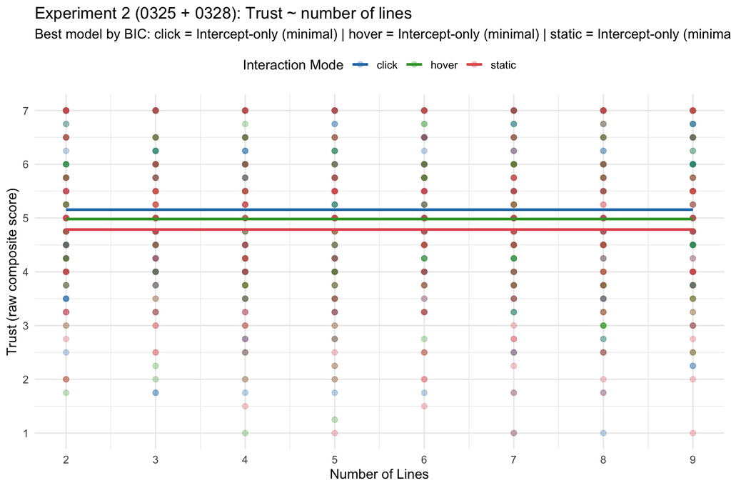

#### Trust model comparison | click

| Model | MSE | LOOCV-MSE | BIC | AIC | Lasso-Regularized MSE |
| --- | --- | --- | --- | --- | --- |
| Intercept-only (minimal) | 1.937305 | 1.949470 | 1131.273 | 1123.736 | 1.937305 |
| Linear | 1.937275 | 1.961647 | 1137.036 | 1125.731 | 1.937394 |
| Quadratic | 1.936474 | 1.972468 | 1142.672 | 1127.599 | 1.940060 |
| Cubic | 1.936428 | 1.985303 | 1148.433 | 1129.591 | 1.943920 |

#### Trust optimal model summary | click

Best model by BIC: `Intercept-only (minimal)`

```
Call:
lm(formula = y ~ 1, data = df)

Residuals:
    Min      1Q  Median      3Q     Max
-4.1562 -0.9062 -0.1562  1.0938  1.8438

Coefficients:
            Estimate Std. Error t value Pr(>|t|)
(Intercept)  5.15625    0.07793   66.17   <2e-16 ***
---
Signif. codes:  0 '***' 0.001 '**' 0.01 '*' 0.05 '.' 0.1 ' ' 1

Residual standard error: 1.394 on 319 degrees of freedom
```

#### Trust model comparison | hover

| Model | MSE | LOOCV-MSE | BIC | AIC | Lasso-Regularized MSE |
| --- | --- | --- | --- | --- | --- |
| Intercept-only (minimal) | 1.506302 | 1.514347 | 1232.932 | 1225.073 | 1.506302 |
| Linear | 1.505947 | 1.522029 | 1238.773 | 1226.984 | 1.506358 |
| Quadratic | 1.505591 | 1.529750 | 1244.614 | 1228.895 | 1.508472 |
| Cubic | 1.504006 | 1.536355 | 1250.147 | 1230.499 | 1.529759 |

#### Trust optimal model summary | hover

Best model by BIC: `Intercept-only (minimal)`

```
Call:
lm(formula = y ~ 1, data = df)

Residuals:
    Min      1Q  Median      3Q     Max
-3.9814 -0.9814  0.0186  1.0186  2.0186

Coefficients:
            Estimate Std. Error t value Pr(>|t|)
(Intercept)  4.98138    0.06338    78.6   <2e-16 ***
---
Signif. codes:  0 '***' 0.001 '**' 0.01 '*' 0.05 '.' 0.1 ' ' 1

Residual standard error: 1.229 on 375 degrees of freedom
```

#### Trust model comparison | static

| Model | MSE | LOOCV-MSE | BIC | AIC | Lasso-Regularized MSE |
| --- | --- | --- | --- | --- | --- |
| Intercept-only (minimal) | 1.913677 | 1.925399 | 1155.290 | 1147.704 | 1.913677 |
| Linear | 1.910092 | 1.933236 | 1160.468 | 1149.089 | 1.911398 |
| Quadratic | 1.908335 | 1.943855 | 1165.960 | 1150.787 | 1.915129 |
| Cubic | 1.907906 | 1.955461 | 1171.679 | 1152.714 | 1.926591 |

#### Trust optimal model summary | static

Best model by BIC: `Intercept-only (minimal)`

```
Call:
lm(formula = y ~ 1, data = df)

Residuals:
    Min      1Q  Median      3Q     Max
-3.7866 -0.7866  0.2134  0.7134  2.2134

Coefficients:
            Estimate Std. Error t value Pr(>|t|)
(Intercept)   4.7866     0.0765   62.57   <2e-16 ***
---
Signif. codes:  0 '***' 0.001 '**' 0.01 '*' 0.05 '.' 0.1 ' ' 1

Residual standard error: 1.385 on 327 degrees of freedom
```

### Interactive Experience ~ number of lines (Click vs Hover vs Static)

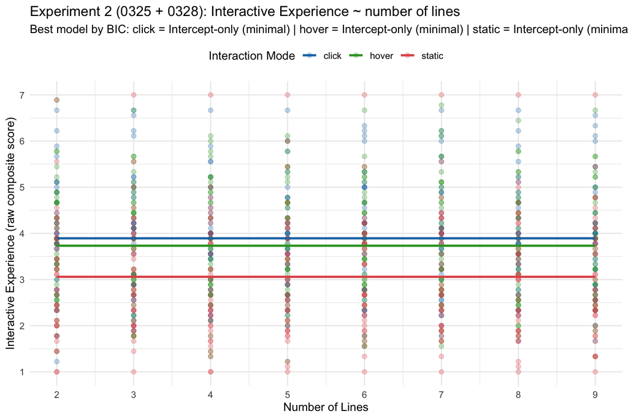

#### Interactive Experience model comparison | click

| Model | MSE | LOOCV-MSE | BIC | AIC | Lasso-Regularized MSE |
| --- | --- | --- | --- | --- | --- |
| Intercept-only (minimal) | 1.275368 | 1.283377 | 997.4925 | 989.9559 | 1.275368 |
| Linear | 1.275289 | 1.291562 | 1003.2408 | 991.9358 | 1.275484 |
| Quadratic | 1.275270 | 1.299651 | 1009.0046 | 993.9313 | 1.275631 |
| Cubic | 1.274083 | 1.306786 | 1014.4749 | 995.6333 | 1.293515 |

#### Interactive Experience optimal model summary | click

Best model by BIC: `Intercept-only (minimal)`

```
Call:
lm(formula = y ~ 1, data = df)

Residuals:
     Min       1Q   Median       3Q      Max
-2.67083 -0.78194 -0.00417  0.44028  2.77361

Coefficients:
            Estimate Std. Error t value Pr(>|t|)
(Intercept)  3.89306    0.06323   61.57   <2e-16 ***
---
Signif. codes:  0 '***' 0.001 '**' 0.01 '*' 0.05 '.' 0.1 ' ' 1

Residual standard error: 1.131 on 319 degrees of freedom
```

#### Interactive Experience model comparison | hover

| Model | MSE | LOOCV-MSE | BIC | AIC | Lasso-Regularized MSE |
| --- | --- | --- | --- | --- | --- |
| Intercept-only (minimal) | 1.389116 | 1.396535 | 1202.480 | 1194.621 | 1.389116 |
| Linear | 1.388727 | 1.403591 | 1208.304 | 1196.515 | 1.389158 |
| Quadratic | 1.388550 | 1.410919 | 1214.186 | 1198.468 | 1.389859 |
| Cubic | 1.388410 | 1.418511 | 1220.078 | 1200.430 | 1.393898 |

#### Interactive Experience optimal model summary | hover

Best model by BIC: `Intercept-only (minimal)`

```
Call:
lm(formula = y ~ 1, data = df)

Residuals:
    Min      1Q  Median      3Q     Max
-2.5101 -0.9545 -0.0656  0.9344  3.1566

Coefficients:
            Estimate Std. Error t value Pr(>|t|)
(Intercept)  3.73227    0.06086   61.32   <2e-16 ***
---
Signif. codes:  0 '***' 0.001 '**' 0.01 '*' 0.05 '.' 0.1 ' ' 1

Residual standard error: 1.18 on 375 degrees of freedom
```

#### Interactive Experience model comparison | static

| Model | MSE | LOOCV-MSE | BIC | AIC | Lasso-Regularized MSE |
| --- | --- | --- | --- | --- | --- |
| Intercept-only (minimal) | 1.529351 | 1.538719 | 1081.758 | 1074.172 | 1.529351 |
| Linear | 1.529333 | 1.548169 | 1087.547 | 1076.168 | 1.529426 |
| Quadratic | 1.529308 | 1.557752 | 1093.335 | 1078.163 | 1.530059 |
| Cubic | 1.529047 | 1.567227 | 1099.072 | 1080.107 | 1.537577 |

#### Interactive Experience optimal model summary | static

Best model by BIC: `Intercept-only (minimal)`

```
Call:
lm(formula = y ~ 1, data = df)

Residuals:
    Min      1Q  Median      3Q     Max
-2.0583 -0.9472 -0.2805  0.8306  3.9417

Coefficients:
            Estimate Std. Error t value Pr(>|t|)
(Intercept)  3.05827    0.06839   44.72   <2e-16 ***
---
Signif. codes:  0 '***' 0.001 '**' 0.01 '*' 0.05 '.' 0.1 ' ' 1

Residual standard error: 1.239 on 327 degrees of freedom
```

### Confidence ~ number of lines (Click vs Hover vs Static)

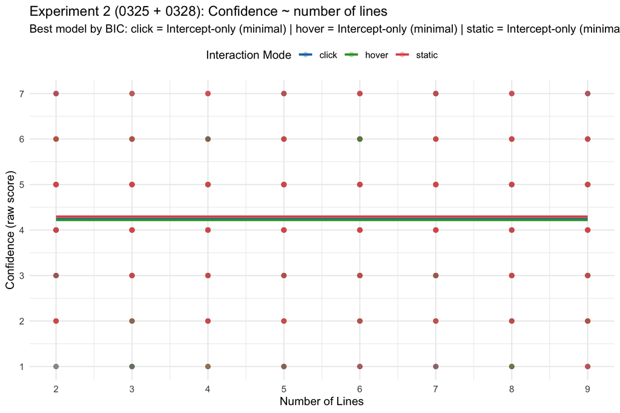

#### Confidence model comparison | click

| Model | MSE | LOOCV-MSE | BIC | AIC | Lasso-Regularized MSE |
| --- | --- | --- | --- | --- | --- |
| Intercept-only (minimal) | 2.446836 | 2.462201 | 1205.992 | 1198.455 | 2.446836 |
| Linear | 2.446834 | 2.477153 | 1211.760 | 1200.455 | 2.446864 |
| Quadratic | 2.440138 | 2.486323 | 1216.651 | 1201.578 | 2.450882 |
| Cubic | 2.440138 | 2.501701 | 1222.420 | 1203.578 | 2.450882 |

#### Confidence optimal model summary | click

Best model by BIC: `Intercept-only (minimal)`

```
Call:
lm(formula = y ~ 1, data = df)

Residuals:
    Min      1Q  Median      3Q     Max
-3.2437 -1.2437 -0.2437  0.7563  2.7563

Coefficients:
            Estimate Std. Error t value Pr(>|t|)
(Intercept)  4.24375    0.08758   48.45   <2e-16 ***
---
Signif. codes:  0 '***' 0.001 '**' 0.01 '*' 0.05 '.' 0.1 ' ' 1

Residual standard error: 1.567 on 319 degrees of freedom
```

#### Confidence model comparison | hover

| Model | MSE | LOOCV-MSE | BIC | AIC | Lasso-Regularized MSE |
| --- | --- | --- | --- | --- | --- |
| Intercept-only (minimal) | 2.427336 | 2.440299 | 1412.336 | 1404.476 | 2.427336 |
| Linear | 2.413455 | 2.438779 | 1416.109 | 1404.320 | 2.416026 |
| Quadratic | 2.412647 | 2.450205 | 1421.912 | 1406.194 | 2.418941 |
| Cubic | 2.403462 | 2.453583 | 1426.408 | 1406.760 | 2.464810 |

#### Confidence optimal model summary | hover

Best model by BIC: `Intercept-only (minimal)`

```
Call:
lm(formula = y ~ 1, data = df)

Residuals:
    Min      1Q  Median      3Q     Max
-3.2207 -1.2207  0.7793  0.7793  2.7793

Coefficients:
            Estimate Std. Error t value Pr(>|t|)
(Intercept)  4.22074    0.08045   52.46   <2e-16 ***
---
Signif. codes:  0 '***' 0.001 '**' 0.01 '*' 0.05 '.' 0.1 ' ' 1

Residual standard error: 1.56 on 375 degrees of freedom
```

#### Confidence model comparison | static

| Model | MSE | LOOCV-MSE | BIC | AIC | Lasso-Regularized MSE |
| --- | --- | --- | --- | --- | --- |
| Intercept-only (minimal) | 2.671689 | 2.688055 | 1264.739 | 1257.153 | 2.671689 |
| Linear | 2.671083 | 2.703579 | 1270.457 | 1259.078 | 2.671620 |
| Quadratic | 2.671030 | 2.720581 | 1276.244 | 1261.072 | 2.672525 |
| Cubic | 2.663728 | 2.730136 | 1281.139 | 1262.174 | 2.714309 |

#### Confidence optimal model summary | static

Best model by BIC: `Intercept-only (minimal)`

```
Call:
lm(formula = y ~ 1, data = df)

Residuals:
    Min      1Q  Median      3Q     Max
-3.2957 -1.2957 -0.2957  0.7043  2.7043

Coefficients:
            Estimate Std. Error t value Pr(>|t|)
(Intercept)  4.29573    0.09039   47.52   <2e-16 ***
---
Signif. codes:  0 '***' 0.001 '**' 0.01 '*' 0.05 '.' 0.1 ' ' 1

Residual standard error: 1.637 on 327 degrees of freedom
```

## Mixed-Effects Regression Tables (2 vs 9 Lines + Interaction Mode)

```r
MODE_LEVELS <- c("click", "hover", "static")
REGRESSION_LINE_LEVELS <- c(2, 9)

format_p_value <- function(x) {
  if (is.na(x)) {
    return(NA_character_)
  }

  if (x < 0.001) {
    return("<0.001")
  }

  formatC(x, format = "f", digits = 3)
}

fit_repeated_measures_model <- function(raw_data, y_col) {
  regression_data <- raw_data %>%
    dplyr::filter(
      interaction_mode %in% MODE_LEVELS,
      condition_number %in% TREATMENT_CONDITION_NUMBERS,
      !is.na(participant_id),
      !is.na(.data[[y_col]])
    ) %>%
    dplyr::mutate(
      participant_id = factor(as.character(participant_id)),
      lines = condition_number - 1
    ) %>%
    dplyr::filter(lines %in% REGRESSION_LINE_LEVELS) %>%
    dplyr::transmute(
      participant_id = participant_id,
      number_of_lines = as.numeric(lines),
      interaction_mode = factor(
        interaction_mode,
        levels = MODE_LEVELS
      ),
      y = as.numeric(.data[[y_col]])
    ) %>%
    droplevels()

  if (nrow(regression_data) == 0) {
    stop("No rows available for repeated-measures regression: ", y_col)
  }

  if (dplyr::n_distinct(regression_data$number_of_lines) < 2) {
    stop("Need both 2-line and 9-line observations for repeated-measures regression: ", y_col)
  }

  if (dplyr::n_distinct(regression_data$interaction_mode) < 3) {
    stop("Need click, hover, and static observations for repeated-measures regression: ", y_col)
  }

  fit <- lmerTest::lmer(
    y ~ number_of_lines * interaction_mode + (1 | participant_id),
    data = regression_data,
    REML = TRUE,
    na.action = na.omit
  )

  fit_summary <- summary(fit)
  fixed_effects <- as.data.frame(coef(fit_summary))
  raw_terms <- rownames(fixed_effects)

  term_labels <- c(
    "(Intercept)" = "Intercept",
    "number_of_lines" = "Number of Lines",
    "interaction_modehover" = "Hover vs click",
    "interaction_modestatic" = "Static vs click",
    "number_of_lines:interaction_modehover" = "Lines x Hover",
    "number_of_lines:interaction_modestatic" = "Lines x Static"
  )
  pretty_terms <- ifelse(raw_terms %in% names(term_labels), term_labels[raw_terms], raw_terms)

  coefficient_table <- data.frame(
    Term = pretty_terms,
    Estimate = round(fixed_effects[, "Estimate"], 4),
    `Std. Error` = round(fixed_effects[, "Std. Error"], 4),
    DF = round(fixed_effects[, "df"], 2),
    `t value` = round(fixed_effects[, "t value"], 4),
    `p value` = vapply(fixed_effects[, "Pr(>|t|)"], format_p_value, character(1)),
    check.names = FALSE,
    row.names = NULL,
    stringsAsFactors = FALSE
  )

  anova_result <- as.data.frame(anova(fit))
  anova_result$Term <- rownames(anova_result)
  rownames(anova_result) <- NULL

  keep_cols <- intersect(
    c("Term", "NumDF", "DenDF", "F value", "Pr(>F)"),
    names(anova_result)
  )
  anova_table <- anova_result[, keep_cols, drop = FALSE]

  if ("NumDF" %in% names(anova_table)) {
    anova_table$NumDF <- round(as.numeric(anova_table$NumDF), 2)
  }
  if ("DenDF" %in% names(anova_table)) {
    anova_table$DenDF <- round(as.numeric(anova_table$DenDF), 2)
  }
  if ("F value" %in% names(anova_table)) {
    anova_table$`F value` <- round(as.numeric(anova_table$`F value`), 4)
  }
  if ("Pr(>F)" %in% names(anova_table)) {
    anova_table$`p value` <- vapply(anova_table$`Pr(>F)`, format_p_value, character(1))
    anova_table$`Pr(>F)` <- NULL
  }

  list(
    fit = fit,
    coefficient_table = coefficient_table,
    anova_table = anova_table,
    n_rows = nrow(regression_data),
    n_participants = dplyr::n_distinct(regression_data$participant_id)
  )
}

regression_metric_specs <- list(
  list(
    display_name = "Trust",
    y_col = "composite_trust_score"
  ),
  list(
    display_name = "Interactive Experience",
    y_col = "composite_interaction_score"
  ),
  list(
    display_name = "Confidence",
    y_col = "confidence_score"
  )
)

for (metric_spec in regression_metric_specs) {
  cat("### ", metric_spec$display_name, " mixed-effects regression\n\n", sep = "")

  model_result <- fit_repeated_measures_model(
    raw_data = composite_treatment,
    y_col = metric_spec$y_col
  )

  cat(
    "Model: `",
    metric_spec$y_col,
    " ~ number_of_lines * interaction_mode + (1 | participant_id)`",
    " using only `2 Lines` and `9 Lines` observations.",
    "\n\n",
    sep = ""
  )
  cat(
    "Rows: ",
    model_result$n_rows,
    " | Participants: ",
    model_result$n_participants,
    "\n\n",
    sep = ""
  )
  cat(
    as.character(
      spaced_kable(
        model_result$coefficient_table
      )
    ),
    sep = "\n"
  )
  cat("\n\n")

  cat("ANOVA:\n\n")
  cat(
    as.character(
      spaced_kable(
        model_result$anova_table
      )
    ),
    sep = "\n"
  )
  cat("\n\n")
}
```

### Trust mixed-effects regression

Model: `composite_trust_score ~ number_of_lines * interaction_mode + (1 | participant_id)` using only `2 Lines` and `9 Lines` observations.

Rows: 256 | Participants: 128

| Term | Estimate | Std. Error | DF | t value | p value |
| --- | --- | --- | --- | --- | --- |
| Intercept | 5.2027 | 0.2417 | 244.4 | 21.5222 | <0.001 |
| Number of Lines | 0.0018 | 0.0286 | 125.0 | 0.0624 | 0.950 |
| Hover vs click | -0.1639 | 0.3289 | 244.4 | -0.4984 | 0.619 |
| Static vs click | -0.2096 | 0.3398 | 244.4 | -0.6170 | 0.538 |
| Lines x Hover | -0.0079 | 0.0390 | 125.0 | -0.2019 | 0.840 |
| Lines x Static | -0.0349 | 0.0402 | 125.0 | -0.8669 | 0.388 |

ANOVA:

| Term | NumDF | DenDF | F value | p value |
| --- | --- | --- | --- | --- |
| number_of_lines | 1 | 125.0 | 0.6035 | 0.439 |
| interaction_mode | 2 | 244.4 | 0.2116 | 0.809 |
| number_of_lines:interaction_mode | 2 | 125.0 | 0.4193 | 0.658 |

### Interactive Experience mixed-effects regression

Model: `composite_interaction_score ~ number_of_lines * interaction_mode + (1 | participant_id)` using only `2 Lines` and `9 Lines` observations.

Rows: 256 | Participants: 128

| Term | Estimate | Std. Error | DF | t value | p value |
| --- | --- | --- | --- | --- | --- |
| Intercept | 3.9417 | 0.1978 | 167.07 | 19.9310 | <0.001 |
| Number of Lines | -0.0111 | 0.0138 | 125.00 | -0.8039 | 0.423 |
| Hover vs click | -0.1467 | 0.2691 | 167.07 | -0.5451 | 0.586 |
| Static vs click | -0.8913 | 0.2780 | 167.07 | -3.2066 | 0.002 |
| Lines x Hover | -0.0010 | 0.0188 | 125.00 | -0.0557 | 0.956 |
| Lines x Static | 0.0103 | 0.0194 | 125.00 | 0.5321 | 0.596 |

ANOVA:

| Term | NumDF | DenDF | F value | p value |
| --- | --- | --- | --- | --- |
| number_of_lines | 1 | 125.00 | 1.0706 | 0.303 |
| interaction_mode | 2 | 167.07 | 6.0225 | 0.003 |
| number_of_lines:interaction_mode | 2 | 125.00 | 0.2183 | 0.804 |

### Confidence mixed-effects regression

Model: `confidence_score ~ number_of_lines * interaction_mode + (1 | participant_id)` using only `2 Lines` and `9 Lines` observations.

Rows: 256 | Participants: 128

| Term | Estimate | Std. Error | DF | t value | p value |
| --- | --- | --- | --- | --- | --- |
| Intercept | 4.2071 | 0.2942 | 249.7 | 14.2994 | <0.001 |
| Number of Lines | -0.0036 | 0.0385 | 125.0 | -0.0928 | 0.926 |
| Hover vs click | 0.5679 | 0.4003 | 249.7 | 1.4188 | 0.157 |
| Static vs click | 0.2354 | 0.4135 | 249.7 | 0.5691 | 0.570 |
| Lines x Hover | -0.0755 | 0.0523 | 125.0 | -1.4415 | 0.152 |
| Lines x Static | -0.0348 | 0.0541 | 125.0 | -0.6427 | 0.522 |

ANOVA:

| Term | NumDF | DenDF | F value | p value |
| --- | --- | --- | --- | --- |
| number_of_lines | 1 | 125.0 | 3.4951 | 0.064 |
| interaction_mode | 2 | 249.7 | 1.0270 | 0.360 |
| number_of_lines:interaction_mode | 2 | 125.0 | 1.0475 | 0.354 |